# Concepts: Transformations

Week 4

Sometimes it is useful to transform the values of a variable before using them to estimate a regression model. There are two types of variable transformations:

- *Linear transformations* will not change the fit of your model or the significance of any of the variable coefficients, but they can make the coefficients and/or the constant easier to interpret.
- *Non-linear transformations* can improve the fit if your model if the actual relationship between a predictor and the outcome is non-linear.

# Linear relationships

If there is a linear relationship between two variables, that means that each one-unit increase in one variable will be associated with a consistent increase in the other. For example, a regression analysis might suggest that the relationship between time spend studying (in minutes) and test scores can be described by the equation:

$$score = 50 + 2*study$$
Which would mean that a student who doesn’t study at all would be predicted to get a score of 50 points on the test, and that each minute spent studying would result in an additional two points on the test. A students who studies for one minute would get a score of 52 on the test. A student who studies for 20 minutes would get a score of 90. Since this is a linear relationship, no matter how much you’ve already studied, each additional minute of studying would always increase your test score by two points.

On a graph, the relationship between studying and test scores would look like this:

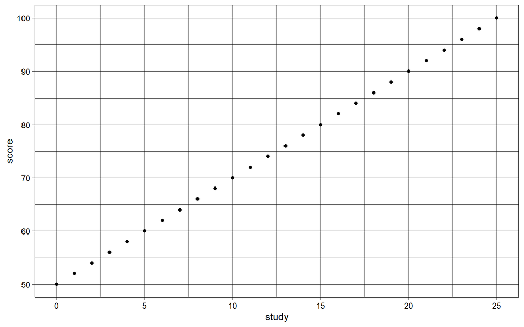

```r
library(tidyverse)

study_data <- tibble(study = seq(0, 25, by=1)) |>
  mutate(score = 50 + study*2)

ggplot(study_data) +
  geom_point(aes(x = study, y = score)) +
  theme_linedraw()
```

## Regression with no transformation

Here are the results of a regression model describing that relationship:

```r
study_model <- lm(score ~ study, data = study_data)

summary(study_model)
```

```
##
## Call:
## lm(formula = score ~ study, data = study_data)
##
## Residuals:
##        Min         1Q     Median         3Q        Max
## -3.966e-14 -1.240e-16  5.120e-16  1.057e-15  3.095e-14
##
## Coefficients:
##              Estimate Std. Error   t value Pr(>|t|)
## (Intercept) 5.000e+01  3.953e-15 1.265e+16   <2e-16 ***
## study       2.000e+00  2.712e-16 7.375e+15   <2e-16 ***
## ---
## Signif. codes:  0 '***' 0.001 '**' 0.01 '*' 0.05 '.' 0.1 ' ' 1
##
## Residual standard error: 1.037e-14 on 24 degrees of freedom
## Multiple R-squared:      1,  Adjusted R-squared:      1
## F-statistic: 5.439e+31 on 1 and 24 DF,  p-value: < 2.2e-16
```

# Linear transformation

Suppose there is a linear relationship between population density and transit ridership. The results of a regression model might look something like this.

```r
rider_model <- lm(riders ~ density, data = rider_data)

summary(rider_model)
```

```
##
## Call:
## lm(formula = riders ~ density, data = rider_data)
##
## Residuals:
##     Min      1Q  Median      3Q     Max
## -6.4901 -1.3723  0.0577  1.5031  6.5601
##
## Coefficients:
##               Estimate Std. Error t value Pr(>|t|)
## (Intercept) -1.919e+00  1.892e-01  -10.14   <2e-16 ***
## density      4.995e-03  6.486e-06  770.17   <2e-16 ***
## ---
## Signif. codes:  0 '***' 0.001 '**' 0.01 '*' 0.05 '.' 0.1 ' ' 1
##
## Residual standard error: 2.037 on 489 degrees of freedom
## Multiple R-squared:  0.9992, Adjusted R-squared:  0.9992
## F-statistic: 5.932e+05 on 1 and 489 DF,  p-value: < 2.2e-16
```

The intercept of the regression is about -2. We can interpret this to mean that in an area with zero people per square mile, we would expect transit ridership to be negative. This is a nonsense and useless observation. There aren’t transit stops in places with zero people per square mile, and negative ridership isn’t a thing.

We can *mean center* our data so that the regression’s intercept does tell us something interesting. Mean-centering means you subtract the average value for a variable from each observation, so the value in the regression doesn’t represent the actual value of the predictor, but rather, the difference between the value and the average for the whole sample.

```r
rider_data <- rider_data |>
  mutate(density_centered = density - mean(density))
```

Now, here’s a regression using the mean-centered predictor:

```r
rider_model <- lm(riders ~ density_centered, data = rider_data)

summary(rider_model)
```

```
##
## Call:
## lm(formula = riders ~ density_centered, data = rider_data)
##
## Residuals:
##     Min      1Q  Median      3Q     Max
## -6.4901 -1.3723  0.0577  1.5031  6.5601
##
## Coefficients:
##                   Estimate Std. Error t value Pr(>|t|)
## (Intercept)      1.255e+02  9.193e-02  1364.7   <2e-16 ***
## density_centered 4.995e-03  6.486e-06   770.2   <2e-16 ***
## ---
## Signif. codes:  0 '***' 0.001 '**' 0.01 '*' 0.05 '.' 0.1 ' ' 1
##
## Residual standard error: 2.037 on 489 degrees of freedom
## Multiple R-squared:  0.9992, Adjusted R-squared:  0.9992
## F-statistic: 5.932e+05 on 1 and 489 DF,  p-value: < 2.2e-16
```

Now, the intercept tells us that when the centered version of the variable is zero (i.e. when the density is at its average value), the expected ridership would be about 125 riders.

We also see (in both versions of this regression) that each additional person per square mile is associated with an increase in ridership of 0.005. That doesn’t sound like much of an effect, but why would it be? An increase of one person per square miles isn’t that much of a difference.

We might be more interested in the effect of an increase in density of 1,000 people per square mile. We can get a coefficient representing the effect of 1,000 additional people per square mile if we divide the density variable by 1,000 before running our model. This is called *scaling* the variable.

```r
rider_data <- rider_data |>
  mutate(density_centered_scaled = density_centered/1000)
```

Now we can run the regression with this centered, scaled predictor.

```r
rider_model <- lm(riders ~ density_centered_scaled, data = rider_data)

summary(rider_model)
```

```
##
## Call:
## lm(formula = riders ~ density_centered_scaled, data = rider_data)
##
## Residuals:
##     Min      1Q  Median      3Q     Max
## -6.4901 -1.3723  0.0577  1.5031  6.5601
##
## Coefficients:
##                          Estimate Std. Error t value Pr(>|t|)
## (Intercept)             1.255e+02  9.193e-02  1364.7   <2e-16 ***
## density_centered_scaled 4.995e+00  6.486e-03   770.2   <2e-16 ***
## ---
## Signif. codes:  0 '***' 0.001 '**' 0.01 '*' 0.05 '.' 0.1 ' ' 1
##
## Residual standard error: 2.037 on 489 degrees of freedom
## Multiple R-squared:  0.9992, Adjusted R-squared:  0.9992
## F-statistic: 5.932e+05 on 1 and 489 DF,  p-value: < 2.2e-16
```

Now that coefficient tells us that a in increase in density of 1,000 people per square mile is associated with a five-person increase in ridership.

Note that none of these linear transformations change the model fit or the significance of any of the relationships.

# Non-linear transformations

Linear regression models allow us to uncover linear relationships. Some variables may have a non-linear relationship with an outcome. A non-linear transformation can help allow you to apply linear regression to determine those relationships.

Two common non-linear transformations are logarithmic transformations and quadratic transformations.

## Logarithmic relationshipos

There are many real-world situations where the incremental effect of some predictor depends on the initial value. The effects of prices or incomes on behavioral outcomes can be like this. The effect of, for example, an additional $10,000 per year in income on your consumption patterns would probably depend a lot on your current income. If your current income is $10,000 per year, that additional $10,000 would represent a doubling of your income, and this might have a dramatic impact on how you spend your time and money. If your current income is $50,000 per year, this would be a 20% increase, which might have a more modest effect on your habits. If your current income is $1,000,000 per year, this would only be a 1% increase, and it might not make much of a difference to you at all.

There may not be a consistent effect for each *absolute* change in income, but there might be a consistent effect for each *relative* change income. For instance, it’s possible that, for each doubling in household income, household members spend ten fewer minutes per day worrying about money. Every time income doubles, the base-two log of income increases by one, so this relationship could be expressed as:

$$worrying = 193-10\times log_2(income)$$

On a graph, that relationship would look like this:

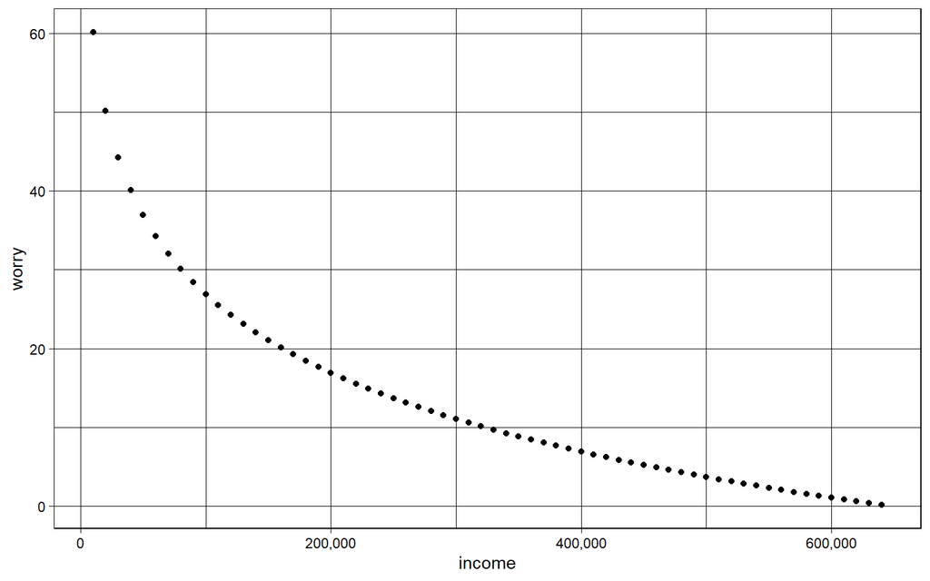

```r
worry_data = tibble(income = seq(10000, 640000,by = 10000)) |>
  mutate(worry = 193 - 10*log2(income))

ggplot(worry_data) +
  geom_point(aes(x = income, y = worry)) +
  scale_x_continuous(breaks = breaks <- seq(0, 600000, by = 200000),
                     labels = formatC(breaks, big.mark = ",", format = "d")) +
  theme_linedraw()
```

### Regression with no transformation

This is not a linear relationship, so even though worrying is perfectly predicted by income, a linear regression model predicting worrying from income won’t have a perfect fit.

```r
worry_model <- lm(worry ~ income, data = worry_data)

summary(worry_model)
```

```
##
## Call:
## lm(formula = worry ~ income, data = worry_data)
##
## Residuals:
##    Min     1Q Median     3Q    Max
## -5.005 -4.102 -1.508  2.414 26.292
##
## Coefficients:
##               Estimate Std. Error t value Pr(>|t|)
## (Intercept)  3.446e+01  1.424e+00   24.20   <2e-16 ***
## income      -6.336e-05  3.810e-06  -16.63   <2e-16 ***
## ---
## Signif. codes:  0 '***' 0.001 '**' 0.01 '*' 0.05 '.' 0.1 ' ' 1
##
## Residual standard error: 5.63 on 62 degrees of freedom
## Multiple R-squared:  0.8169, Adjusted R-squared:  0.8139
## F-statistic: 276.6 on 1 and 62 DF,  p-value: < 2.2e-16
```

But there is still a linear relationship between worry and the log of income.

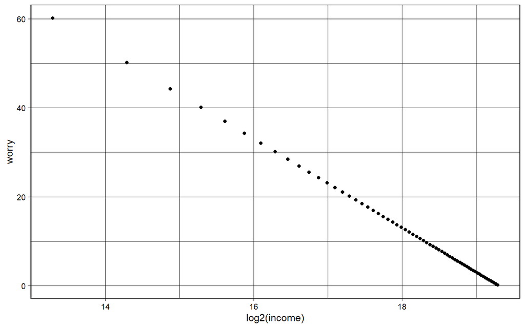

```r
ggplot(worry_data) +
  geom_point(aes(x = log2(income), y = worry)) +
  theme_linedraw()
```

### Regression with a log transformation

So if we fit a linear regression model predicting worry with the log of income, we get a much better fit.

```r
worry_model <- lm(worry ~ log(income, 2), data = worry_data)

summary(worry_model)
```

```
##
## Call:
## lm(formula = worry ~ log(income, 2), data = worry_data)
##
## Residuals:
##        Min         1Q     Median         3Q        Max
## -2.128e-14 -5.585e-15  1.029e-15  8.417e-15  4.649e-14
##
## Coefficients:
##                  Estimate Std. Error    t value Pr(>|t|)
## (Intercept)     1.930e+02  1.812e-14  1.065e+16   <2e-16 ***
## log(income, 2) -1.000e+01  1.009e-15 -9.910e+15   <2e-16 ***
## ---
## Signif. codes:  0 '***' 0.001 '**' 0.01 '*' 0.05 '.' 0.1 ' ' 1
##
## Residual standard error: 1.045e-14 on 62 degrees of freedom
## Multiple R-squared:      1,  Adjusted R-squared:      1
## F-statistic: 9.82e+31 on 1 and 62 DF,  p-value: < 2.2e-16
```

It’s worth pointing out that we get the same model fit for a log of any base (although the coefficient and its interpretation would change).

In the above model results, the income coefficent can be interpreted as the effect of doubling income.

If we use a base-ten log, the coefficient is the effect of a ten-fold increase in income, but the overall model fit is the same, and so is the value of the constant.

```r
worry_model_10 <- lm(worry ~ log(income,10), data = worry_data)

summary(worry_model_10)
```

```
##
## Call:
## lm(formula = worry ~ log(income, 10), data = worry_data)
##
## Residuals:
##        Min         1Q     Median         3Q        Max
## -7.957e-14 -6.733e-15 -4.280e-16  1.172e-14  3.039e-14
##
## Coefficients:
##                   Estimate Std. Error    t value Pr(>|t|)
## (Intercept)      1.930e+02  3.179e-14  6.071e+15   <2e-16 ***
## log(income, 10) -3.322e+01  5.880e-15 -5.649e+15   <2e-16 ***
## ---
## Signif. codes:  0 '***' 0.001 '**' 0.01 '*' 0.05 '.' 0.1 ' ' 1
##
## Residual standard error: 1.834e-14 on 62 degrees of freedom
## Multiple R-squared:      1,  Adjusted R-squared:      1
## F-statistic: 3.191e+31 on 1 and 62 DF,  p-value: < 2.2e-16
```

When the base of logarithm isn’t specified, it’s generally going to be a natural log, which means you’d interpret the coefficient as the effect of increasing the value of the predictor by a factor of about 2.7.

```r
worry_model <- lm(worry ~ log(income), data = worry_data)

summary(worry_model)
```

```
##
## Call:
## lm(formula = worry ~ log(income), data = worry_data)
##
## Residuals:
##        Min         1Q     Median         3Q        Max
## -3.287e-14 -7.508e-15 -1.480e-16  1.018e-14  2.380e-14
##
## Coefficients:
##               Estimate Std. Error    t value Pr(>|t|)
## (Intercept)  1.930e+02  2.290e-14  8.429e+15   <2e-16 ***
## log(income) -1.443e+01  1.839e-15 -7.843e+15   <2e-16 ***
## ---
## Signif. codes:  0 '***' 0.001 '**' 0.01 '*' 0.05 '.' 0.1 ' ' 1
##
## Residual standard error: 1.321e-14 on 62 degrees of freedom
## Multiple R-squared:      1,  Adjusted R-squared:      1
## F-statistic: 6.151e+31 on 1 and 62 DF,  p-value: < 2.2e-16
```

### Unwinding a logarithmic transformation

Since worrying is apparently perfectly predicted by income, if you tell me how much worrying someone does, I should be able to tell you their income.

What if you tell me they worry about money for 25 minutes per day?

My regression with a base-2 log told me that:

$$worrying = 193-10\times log_2(income)$$

So if someone worries for 25 minutes per day:

$$193-10\times log_2(income) = 25$$

$$log_2(income) = 16.8$$

$$income = 2^{16.8} = 114,104.8$$

When I estimated regression with a base-10 log, I got this equivalent formula:

$$worrying = 193-33.22\times log_{10}(income)$$

So again, if someone worries for 25 minutes per day:

$$193-33.22\times log_{10}(income) = 25$$

$$log_{10}(income) = 5.057$$

$$income = 10^{5.057} = 114,104.8$$

When I estimated regression with a natural (base ~2.7) log, I got this equivalent formula:

$$worrying = 193-14.43\times ln(income)$$

So again, if someone worries for 25 minutes per day:

$$193-14.43\times ln(income) = 25$$

$$ln(income) = 11.645$$

$$income = e^{11.64487} = 114,104.8$$

The function for raising e to a power in both R and Excel is `exp()`.

## Quadratic relationships

Log transformations are by far the most common non-linear transformation you’re likely to come across in linear regression.

Quadratic realtionships will occasionally be a useful way to model the effect of age on an outcome. There are many outcomes might increase with age up to a certain maximum age, aad then they decrease after that.

For example, a typical tennis player’s abilities might be lower at younger ages (when they are still inexperienced and have shorter arms), and increase with age (as they get stronger and more experienced). Then, at a certain age, they might start to lose some abilities due to injury or other effects of age.

In that case, the relationship between tennis ability and age might look like this:

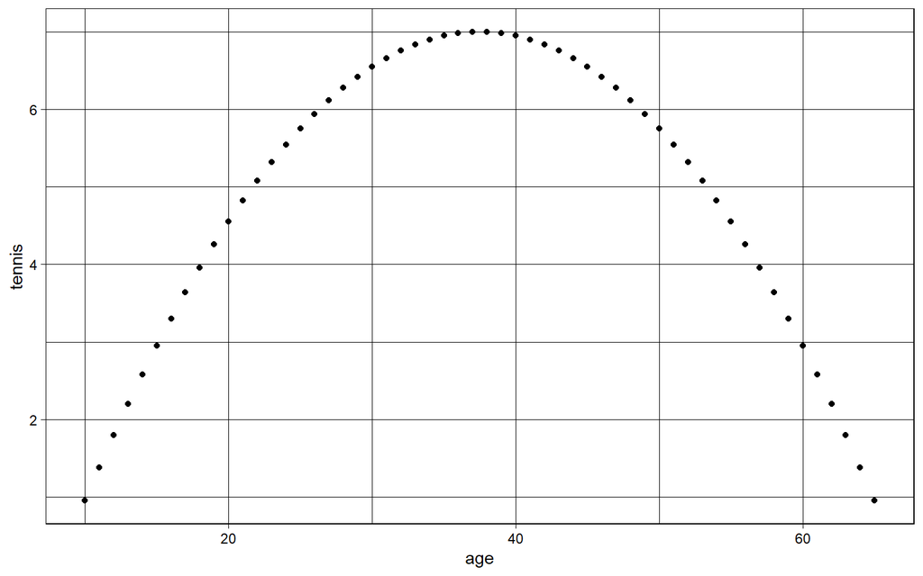

```r
tennis_data <- tibble(age = seq(10, 65, by = 1)) |>
  mutate(tennis = -4.25 + 0.6*age - 0.008*age^2)

ggplot(tennis_data) +
  geom_point(aes(x = age, y = tennis)) +
  theme_linedraw()
```

Which also kind of looks like the path a tennis ball might take through the air.

The equation describing this relationship is a quadratic equation with a single predictor:

$$tennis = -4.25 + 0.6(age) - 0.008(age^2)$$

### Regression with no transformation

Again, if we try to estimate the effect of age on tennis ability when this is the relationship, we would find that age doesn’t have an effect on tennis.

```r
tennis_model <- lm(tennis ~ age, data = tennis_data)

summary(tennis_model)
```

```
##
## Call:
## lm(formula = tennis ~ age, data = tennis_data)
##
## Residuals:
##    Min     1Q Median     3Q    Max
## -3.960 -1.356  0.520  1.668  2.088
##
## Coefficients:
##               Estimate Std. Error t value Pr(>|t|)
## (Intercept)  4.910e+00  6.424e-01   7.643 3.72e-10 ***
## age         -7.343e-18  1.573e-02   0.000        1
## ---
## Signif. codes:  0 '***' 0.001 '**' 0.01 '*' 0.05 '.' 0.1 ' ' 1
##
## Residual standard error: 1.903 on 54 degrees of freedom
## Multiple R-squared:  6.456e-32,  Adjusted R-squared:  -0.01852
## F-statistic: 3.486e-30 on 1 and 54 DF,  p-value: 1
```

### Regression with a quadradic transformation

But we could estimate this relationship using a linear regression model with two predictors: age and age-squared.

```r
tennis_data <- tennis_data |>
  mutate(age_squ = age^2)

tennis_model <- lm(tennis ~ age + age_squ, data = tennis_data)

summary(tennis_model)
```

```
##
## Call:
## lm(formula = tennis ~ age + age_squ, data = tennis_data)
##
## Residuals:
##        Min         1Q     Median         3Q        Max
## -1.146e-14 -1.992e-15 -3.753e-16  1.286e-15  3.097e-14
##
## Coefficients:
##               Estimate Std. Error    t value Pr(>|t|)
## (Intercept) -4.250e+00  3.676e-15 -1.156e+15   <2e-16 ***
## age          6.000e-01  2.180e-16  2.753e+15   <2e-16 ***
## age_squ     -8.000e-03  2.854e-18 -2.804e+15   <2e-16 ***
## ---
## Signif. codes:  0 '***' 0.001 '**' 0.01 '*' 0.05 '.' 0.1 ' ' 1
##
## Residual standard error: 4.987e-15 on 53 degrees of freedom
## Multiple R-squared:      1,  Adjusted R-squared:      1
## F-statistic: 3.93e+30 on 2 and 53 DF,  p-value: < 2.2e-16
```

You can’t really interpret the coefficients for age and age-squared separately. If the coefficient for age-squared is significant and negative and coefficient for age is significant and positive, that tells you that the value for the outcome increases with age up to a certain point, and then begins to decrease with age.

### Unwinding a quadradic transformation

Since tennis ability is perfectly predicted by age, we should be able to calculate a person’s age based on their tennis ability.

This will require us to dust off the old quadratic equation.

When:

$$ax^2 + bx + c = 0$$

We can solve for x using the formula:

$$x = \frac{-b \pm \sqrt{b^2 - 4ac}}{2a}$$

So if my regression suggests that the relationship between tennis and age is:

$$tennis = -4.25 + 0.6(age) - 0.008(age^2)$$

And I want to know the age(s) at which a person would have a tennis rating of 5.0, I would set up the equation as:

$$-4.25 + 0.6(age) - 0.008(age^2) = 5$$

Which is the same as:

$$- 0.008(age^2) + 0.6(age) - 9.25 = 0$$

Which I can solve as:

$$age = \frac{-0.6 \pm \sqrt{0.6^2 - 4(-9.25)(-0.008)}}{2(-0.008)}$$

```r
(-0.6 + sqrt(0.6^2 - 4*-9.25*-0.008))/(2*-0.008)
```

```
## [1] 21.68861
```

```r
(-0.6 - sqrt(0.6^2 - 4*-9.25*-0.008))/(2*-0.008)
```

```
## [1] 53.31139
```

Which would give me two possible values for age: 21 and 53.